# CC5206 Introducción a la Minería de Datos: Reporte Hito 3

Integrantes: Benjamín Farías, Tomás Letelier, Diego León, Joaquín Moraga

## Motivación

Durante los últimos años debido a la tecnología se han desarrollados miles de aplicaciones para los dispositivos emergentes por lo que distintas empresas han fijado sus ojo en esta nueva oportunidad de mercado, por ejemplo, durante el periodo de pandemia del COVID-19, la app store de la empresa apple a tenido un crecimiento en sus descargas de un 7% registrando 218 billones de descargas totales. Con este nuevo comportamiento las personas están pasando aproximadamente 4 horas al día en aplicaciones dentro de sus dispositivos móviles, independientemente de su rango de edad, generando así un crecimiento en este mercado, pues el 26% de los dólares generados globalmente están ligados a negocios que ofrecen algún tipo de aplicación móvil.

Si bien este mercado presenta una oportunidad de negocio tentativa, si es que se presenta el capital necesario, primero se debe realizar un estudio de mercado, pues aproximadamente entre un 80 a 90% de las aplicaciones recién lanzadas al mercado son abandonadas en su primera etapa debido a la mala percepción popular, es por esta razón que se deben explorar puntos claves en el estudio de mercado.

En base a lo anterior, es de interés estudiar las relaciones existentes entre las aplicaciones, tales como las aplicaciones más utilizadas y mejor calificadas, aplicaciones con mayor número de instalaciones, aplicaciones con mejores (o peores) comentarios, etc. Dichas relaciones, podrían dar indicios del porqué una ciertas aplicaciones son las más descargadas (importancia de tales aplicaciones en la vida de hoy, y que tan necesarias son para las personas), o revelar, en base a las aplicaciones más utilizadas, conductas inducidas en las personas por las mismas.

Al interés de estudiar datos del mercado de aplicaciones se suma, la preponderancia que tienen los smartphones y sus aplicaciones, en la vida cotidiana de las personas. Con el pasar del tiempo, las empresas desarrolladoras de aplicaciones han logrado vincularse con distintas costumbres y culturas humanas, teniendo una inmensa variedad de funcionalidades accesibles por las aplicaciones, que influyen en la vida de personas de formas muy variadas. Tales hábitos revelan factores importantes en los contextos sociales, económicos, políticos y culturales de los distintos países del mundo. Con los puntos a estudiar ya fijos, se tomó la decisión de estudiar un conjunto de datos recolectados de la tienda de aplicaciones Google Play, disponible en Kaggle. El dataset consiste básicamente de 2 tablas, la primera presenta información sobre las aplicaciones, como atributos de categoría, clasificación, cantidad de reseñas y tamaño aproximado. La segunda tabla contiene datos de las 100 reseñas más representativas de un conjunto de aplicaciones, en esta se encuentra información sobre la reseña, el carácter positivo, negativo o neutral de la reseña, que tan objetiva o subjetiva es y la calidad de redacción de esta.

## Exploracion de Datos

Para iniciar la exploración de datos, se seleccionan las tablas más relevantes. Originalmente el dataset contenía 5 tablas, sin embargo 2 de estas corresponden a versiones extendidas del resto, por lo que el contenido útil se reduce a 2 dataframes, uno con información de las aplicaciones y otro de las reseñas. En adelante nos referiremos a estas como ‘Apps’ y ‘Reviews’ respectivamente.

### Apps

La tabla ‘Apps’ consta de 9659 filas, cada una correspondiente a una aplicación distinta y 23 columnas con los atributos de las mismas. Las aplicaciones se identifican por la primera columna, ‘App’, que contiene el nombre de las mismas.

La columna “Rating” muestra la puntuación del 1 al 5 dada por los usuarios para cada aplicación. Tiene un promedio de 4.173, mediana 4.3 y rango intercuartil 0.5. Contiene 1463 valores faltantes.

La columna “Size” muestra el tamaño en MB de las aplicaciones. Tiene un mínimo de 0.0085, máximo de 100, media 20.39529, mediana 12 y rango intercuartil 23.4. Contiene 1227 valores faltantes. Cortando el 10% de valores extremos la media baja a 16.26433.

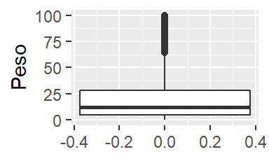

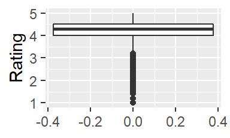

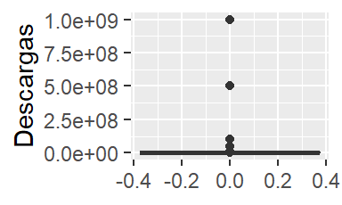

La intersección de valores faltantes entre “Rating” y “Size” es de 58 filas.

La columna “Reviews” muestra el número de reviews que ha recibido cada aplicación. Tiene un mínimo de 0, máximo de 78158306, media 216593, mediana 967, rango inter cuartil 29376 y desviación estándar 1831320. Extrayendo el 1% de los valores extremos la media se reduce a 100217.1. Extrayendo el 10% se reduce 19295.5.

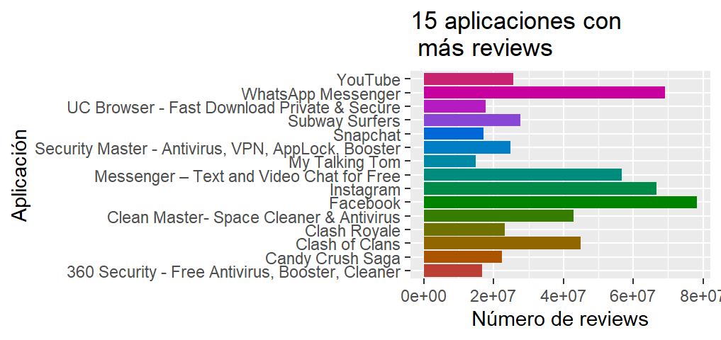

La columna “Installs” muestra el número de descargas de cada aplicación. Tiene un mínimo de 0, máximo de 10^9, media 7.778*10^6, mediana 10^5, primer cuartil 10^3 y tercer cuartil 10^6.

La columna “Type” asigna 0 a las aplicaciones gratis y 1 a las que no lo son, esto también se indica de forma categórica en la columna “Type..categorical.”. En total hay 756 aplicaciones de pago y 8903 gratis. El valor de la fila 8903 es -1, debería ser 0.

La columna “Price” muestra el precio de las aplicaciones. Entre las aplicaciones de pago, el mínimo es 0.99, el máximo 400, la media 14.04515, la mediana 2.99 y la desviación estándar 58.74361. Extrayendo el 5% de los valores extremos, la media se reduce a 4.027639.

Las columnas “Category” y “Genres” contienen valores numéricos, cada uno asociado a una categoría y un género respectivamente, que se especifican en las columnas “Category..categorical.” y “Genres..categorical.”. Se construyeron 2 dataframes: ‘Cat’ con una fila asociada a cada categoría y ‘Gen’ con una fila asociada a cada género, además incluyen columnas con el número que corresponde a las distintas categorías o género, y el total de aplicaciones y descargas de cada uno. En total hay 33 categorías y 118 géneros

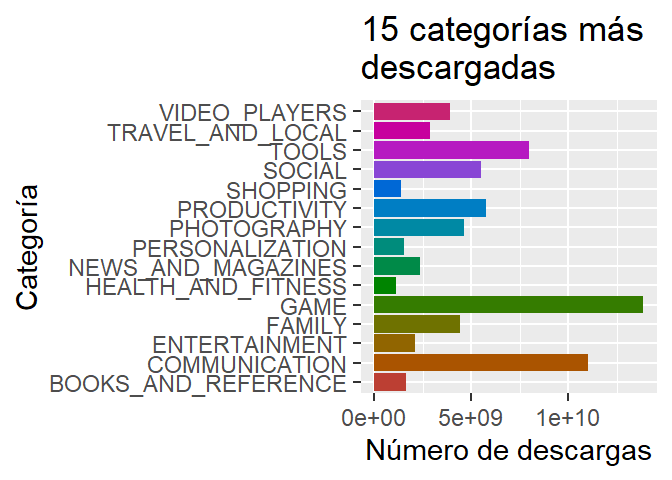

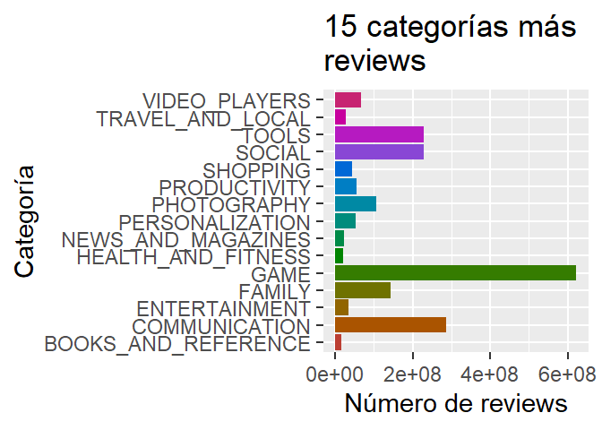

Las aplicaciones que son juegos son los más pesados en temas de tamaño de aplicación, seguidas de aplicaciones de categoria “familia”, teniendo luego como categorias notables la de “autos y vehiculos”, “deportes” y “travel” como categorias que tienden a tener aplicaciones con mayor peso.

Respecto al precio, las aplicaciones de las categoria finanzas tienden a ser las más caras, seguido de las aplicaciones en categorias de “business” y “medicina”

Además de esto, se visualiza por separado la correlación de los ratings de las aplicaciones en comparación con su precio y tamaño. Se separa además aquellas aplicaciones con precios extremadamente altos (sobre 50 USD) ya que estas Apps tienden a ser intencionalmente caras solo con el objetivo de ser caras (existen apps cuyo único propósito es ser caras. Ej: Apps “Im Rich”).

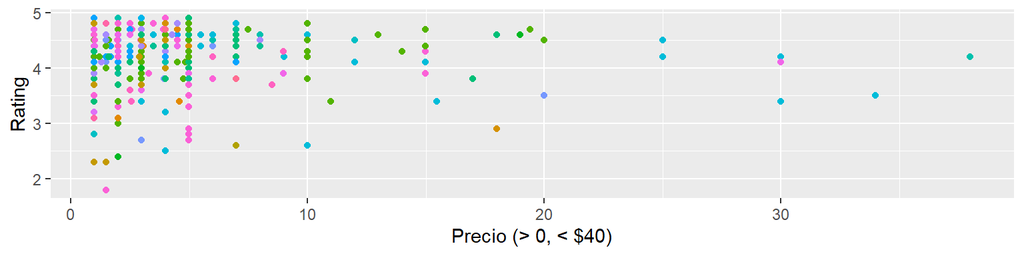

Se observa cómo hasta un cierto punto, las aplicaciones más caras tienden a tener un mayor minimo de ratings. Las aplicaciones más caras no son necesariamente las mejores, pero en general el su peor rating no baja de 3* a partir de cierto precio.

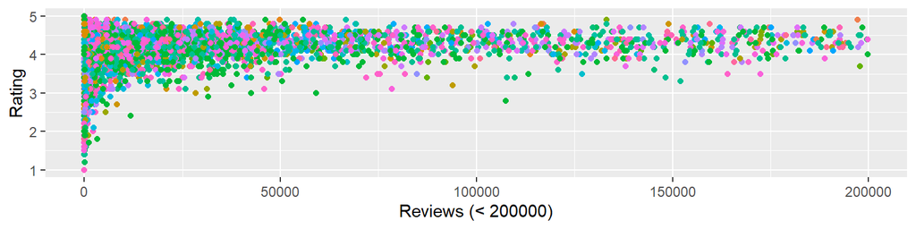

También se observa como, aunque en general no existe una correlación muy marcada entre la cantidad de reviews de una aplicación y su rating final, se observa como las aplicaciones consideradas más malas tienden a tener mucho menos cantidad de reviews totales.

### Reviews

La tabla ‘Reviews’ contiene 64295 y 33 columnas. Cada fila corresponde a una reseña de los usuarios sobre las aplicaciones. La primera columna indica la aplicación, la segunda contiene el texto de la review y las 31 restantes muestran datos del texto, tales como el número de caracteres o si la reseña es positiva o negativa. La tabla posee 26868 filas que no contienen información del texto, por lo que son removidas del dataframe.

Las columnas de la 3 a la 17 contienen datos numéricos sobre el texto, del tipo número de caracteres, número de palabras, número de espacios, etc.

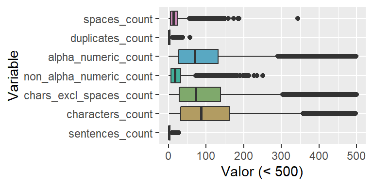

La columna “sentiment_polarity_score” contiene valores continuos entre -1 y 1, que representan el grado de negatividad, si es cercano a -1, o positividad, si es cercano a 1, de la review. Tiene media 0.1822 y mediana 0.15. Las columnas “sentiment_polarity” y “sentiment_polarity_summarised” descriven la variable categóricamente.

La columna “sentiment_sunjetivity_score” contiene valores continuos de 0 a 1, que indican el grado de objetividad, si es cercano a 0, o subjetividad, si es cercano a 1, de la review. Tiene media 0.4929 y mediana 0.5143. La columna “sentiment_sunjetivity” descrive la variable categóricamente.

La columna “spelling_quality_score” contiene valores continuos de 0 a 1, que tan mal, si es cercano a 0, o bien, si es cercano a 1, escrita está la review. Tiene media 0.893 y mediana 0.918. Las columnas “spelling_quality” y “spelling_quality_summarised” descriven la variable categóricamente.

La columna “ease_of_reading_score” contiene valores continuos de -1570.79 a 206.84, que tan difícil, si es cercano a 0, o fácil, si es cercano a 1, de leer es la review. Tiene media 74.03 y mediana 74.53. Las columnas “ease_of_reading_quality” y “ease_of_reading_summarised” descriven la variable categóricamente.

Se reescaló “ease_of_reading_score” al rango [-1, 1].

La gran mayoría de los comentarios se pueden considerar “neutrales”, en el sentido de que no son completamente objetivos ni subjetivos. De hecho, si uno compara la cantidad de comentarios que se consideran objetivos o subjetivos, es posible notar que en su totalidad están relativamente equilibrados.

Se calcula la correlación lineal entre las variables numéricas:

- Todas las correlaciones, menos entre subjetividad y polaridad, tienen magnitudes menores a 0.13.
- La mayor correlación se ve entre polaridad y subjetividad.
- La polaridad es directamente proporcional a la subjetividad, lo cuál puede indicar que el gusto por una aplicación puede llevar a la gente a hablar mejor de ella sin tanta objetividad.
- Tanto la facilidad de lectura como la calidad de escritura de los comentarios son inversamente proporcionales a los errores gramaticales, lo cuál tiene sentido, pues mientras peor escritas estén las palabras, menor es la probabilidad de lograr entender el mensaje.
- La polaridad es inversamente proporcional a los errores gramaticales, lo que podría indicar que mientras menos le agrade a un individuo una aplicación, tenderá a escribir peor su review.

### Cruce de Tablas

La tabla ‘Reviews’ contempla 865 aplicaciones distintas, de las cuales 816 están en ‘Apps’. Se creó un dataframe ‘Apps/Reviews’ con la filas y columnas de ‘Apps’ que correspondientes a aplicaciones que están en ‘Reviews’, más columnas con los promedios de “sentiment_polarity_score”, “ease_of_reading_score”, “sentiment_subjectivity_score”, “spelling_quality_score” y algunas variables de conteos como “characters_count”, y el total de reviews concideradas en ‘Reviews’.

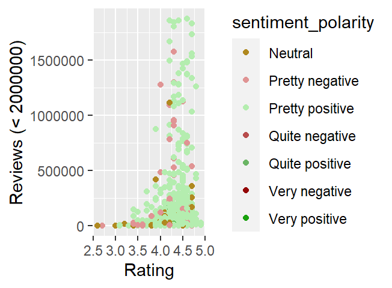

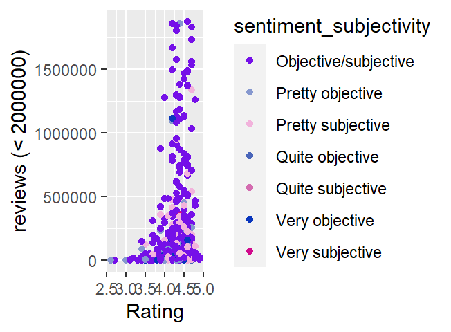

Las reviews por aplicación tienen un de mínimo 1, primer cuartil 28, media 37, tercer cuartil 40, máximo 312 y media 44.

La polaridad tiene un mínimo de -0.5, máximo de 1, media 0.20052, mediana 0.19822 y rango intercuartil 0.21689.

La facilidad de lectura tiene un mínimo de 0.7841, máximo de 0.9037, media 0.8507, mediana 0.8499 y rango intercuartil 0.0157.

La subjetividad tiene un mínimo de 0, máximo de 0.9167, media 0.492, mediana 0.4971 y rango intercuartil 0.0852.

La calidad de escritura tiene un mínimo de 0.6667, máximo de 1, media 0.8913, mediana 0.8968 y rango intercuartil 0.0449.

La cantidad de reviews tiene un mínimo de 114, máximo de 78158306, media 711392, mediana 40650 y rango intercuartil 190567.

La columna “Rating” de ‘Apps/Reviews’ no tiene valores faltantes. En “Size” faltan 248.

Sólo 9 aplicaciones no son gratis.

Matriz de correlación:

```
##             [,1]        [,2]        [,3]        [,4]        [,5]        [,6]
## [1,]  1.00000000 -0.14140878 -0.01249756  0.02425321 -0.07754995  0.05417332
## [2,] -0.14140878  1.00000000  0.19049552  0.32038004  0.03906013  0.26405321
## [3,] -0.01249756  0.19049552  1.00000000  0.05640964 -0.11048526  0.07695201
## [4,]  0.02425321  0.32038004  0.05640964  1.00000000 -0.06932779  0.21548787
## [5,] -0.07754995  0.03906013 -0.11048526 -0.06932779  1.00000000 -0.01832191
## [6,]  0.05417332  0.26405321  0.07695201  0.21548787 -0.01832191  1.00000000
```

- sentiment_polarity_score
- ease_of_reading_score
- sentiment_subjectivity_score
- spelling_quality_score
- Rating
- Reviews

Se mantienen las 33 categorías y 67 de los 118 géneros de “Extended Google Playstore”

## Preguntas y problemas

Basado en lo explicado en las secciones de motivación y análisis exploratorio surgen las siguientes preguntas/problemas que se podrían responder usando la refactorización de los datos para poder entender de mejor manera el comportamiento de las descargas de aplicaciones. Las preguntas son las siguientes:

- **1:** ¿Es posible predecir la cantidad de descargas de una aplicación, en base al público dirigido y las funcionalidades que la aplicación ofrece al público?¿Se puede hacer la misma preducción con los datos de las reviews?¿Es posible también predecir el rating?
- **2:** ¿Es posible caracterizar tipos de aplicaciones respecto a los reviews recibidos por los usuarios?
- **3:** ¿Existen características específicas de las aplicaciones que permitan tener mejor o peor aprobación del público?

## Propuesta Metodológica Experimental Inicial

### Preprocesamiento

El dataframe ‘Apps’ se subdivide según categoría, escogiendo sólo las 10 con más descargas. En cada categoría se eliminan los outliers del número de descargas (en base al gráfico de caja). Se remueven las filas con valores faltantes de “Size” y “Rating”.

Para porder utilizar “Content.Rating” en todos los modelos, se reemplazan sus valores cualitativos “Everyone”, “Everyone 10+”, “Teen”, “Mature 17+” y “Adults only 18+”, por 0.0, 0.5, 1.0, 1.5 y 2.0 respectivamente. Se eliminan filas con “Unrated”.

Se agregan columnas que indican a que decil y cuartil de descargas y rating respectivamente, según cetegoría, pertenece cada aplicación.

De ‘Reviews’ se remueven las aplicaciones que no están en ‘Apps’.

Del dataframe ‘Apps/Reviews’ se selecionan las aplicaciones por sobre el primer cuartil de reviews consideradas en ‘Reviews’ (más de 28) para realizar clustering en base a los ‘scores’ y los conteos de: caracteres, palabras, oraciones, espacios, caracteres alfa-numéricos, puntuaciones y sintagma nominal (noun phrase). No se utilizarán los conteos de emojis, duplicados, fechas y números enteros debido a que en la mayoría de los casos son 0, tampoco el promedio de caracteres no alfa-numéricos ya que es complemento de el de caracteres alfa-numéricos.

Los promedios de espacios, caracteres alfa-numéricos y puntuaciones se transforman a un espacio relativo dividiendolos por el promedio de caracteres. Los promedios de caracteres, palabras, oraciones y sintagma nominal se normalizan al espacio [0,1].

Se agregan los cuartiles 1 y 3 de los “scores”. También se eliminan outliers del número de descargas y se agrega una columna que indica a que cuartil (de descargas) pertenece cada aplicación.

### Clasificación

Las preguntas 1 y 3 son problemas de predicción, por lo tanto para estas recurriremos a modelos de clasificación. Para poder clasificar se discretiza la variable a predecir según cuartiles (después de extraer outliers). De este modo se consiguen tamién clases balanceadas, ya que cada una contiene el 25% de las aplicaciones.

**Aplicaciones:**

Se considera el rating, número de reseñas, peso, público objetivo y si es de pago o no para clasificar las descagas según cuartiles (pregunta 1). Se clasifica el rating según cuartiles con los mismo atributos, reemplazando “Rating” por “Installs” (Pregunta 3). No se concidera el género debido a que pueden existir combinaciones categoría/género no contempladas en los datos.

Se repiten las clasificaciones de descargas y rating para apliciones de pago, incluyendo el precio en los atributos a evaluar (extrayendo outliers).

**Reseñas:**

La clasificación en base a resseñas se divide en dos partes. Primero se evaluará la posibilidad de extrar información del comentario de las reviews. Para ello se vectoriza el texto y luego se reduce la dimensionalidad por medio de *Latent semantic analysis*. Se utilizan los datos del texto para clasificar “sentiment_polarity”, “sentiment_subjectivity” y “spelling_quality”. En la vectorización del texto no se consideran *stop words*, ya que palabras comunmente categorizadas como tal podrían aportar información para el nivel de subjetividad o facilidad de lectura.

Para la segunda parte se evaluan los datos de ‘Apps/Reviews’ para clasificar los cuartiles y deciles de rating y descargas. Para este caso no se subdivide por categoría debido a la menor cantidad de aplicaciones que contiene el dataframe.

Para todas las clasificaciones mencionadas se utlizan los modelos de árbol de decisión, KNN, naive bayes y support vector machines. Para evaluar los resultados de la clasificación se hará uso de cross validation con distribución 80/20 entre datos de entrenamiento y prueba, y considerarán las métricas: exactitud, precisión, recall y F1.

### Clustering

La pregunta 2 se abordará por medio de clustering.

Sobre los datos de ‘Apps/Reviews’ se aplican los siguentes métodos: *K*-means, con valores de *k* obtenidos según optimos observables en un gráfico de codo; clustering jerárquico aglomerativo, con criterios *complete*, *average*, *single* y *ward*; y DBSCAN con valores de *eps* y *minPts* dados por la distancia media a los *k* vecinos y el doble de la dimensionalidad del dataset respectivamente, ambos valores se toman como base y se variarán según los resultados.

Se tendrán dos enfoques para evaluar los clusters. La primera se centra en los propios datos usados para crear los clusters, es decir el de las reviews. Los resultados se evaluan en base a cohesión (SSE) y coeficiente de Silhouette. Para visualizar los resultados se reduce la dimensionalidad con el método *principal component analisys*, de modo que sea posible crear un gráfico de disperción. También se estudia la distribución de loss atributos en los clusters resultantes, en específico las medias y cuartiles.

Para este caso se podrían aplicar más filtros y dividir los datos en subconjuntos más homogéneos (según número de descargas, categorías, content rating, ect.) sin embargo, el dataset actual ya es demasiado pequeño (607 filas).

La segunda opción es evaluar la posibilidad de que, por medio de sus reviews, se logre caracterizar las aplicaciones según datos externos a esta, como lo son la categoría o el rating. En este caso se evaluan los resultados comprobando las diferencias y similitudes de las aplicaciones de los clusters resultantes, según sus atributos en el dataframe ‘Apps’. Para ello se considera que fracción de categorías, géneros y content rating se encuentran en cada cluster, junto con el porcentanje de la clase mayoritaria en cada caso. Se considerará también la media de rating de cada cluster. Estos resultados también pueden ser útiles para responder la pregunta 3.

Para ambos casos se evalua también con medida de información mutua, comparando los clusters con distintos atributos del dataset.

Adicionalmente, se realiza clustering con los métodos ya mencionados sobre el dataset ‘Apps’. Si se encuentran clusters consistentes, se repite la parte de clasificación sobre estos datos.

## Procedimiento Experimental

Para cada pregunta se realiza una segunda selección y reducción de atributos, en la que se normalizan datos, remueven outliers, evalua correlación, filtra según clusters y se reduce la dimensionalidad de los datos del texto.

A partir de las matrices de correlación se obtuvo que:

Se econtró también que el número de descarga sigue una distribución tal que es reemplazable por una variable discreta, obtenida mediante clustering.

## Resultados

### Análisis de Texto

A partir del texto de las reviews, en general, la polaridad se logra clasificar mejor que la polaridad y la calidad de lectura, y la support vector machine obtiene mejores resultados para los 3 casos.

Para la SVM, en la clasificación de polaridad, todas las métricas son un poco mayores a 0.7, menos recall y f1 macro que están por debajo de 0.5 y 0.6 respectivamente. En las clasificaciones de subjetividad y calidad se obtiene valores inferiores a 0.6 y 0.5.

### Pregunta 1

Sobre el dataset dividido por categorías, con el número de reviews como input, el desempeño del árbol de decisión es significativamente mayor a los otros 3 modelos, con valores cercanos a 0.7 en las 7 métricas evaluadas.

Sobre las aplicaciones de pago la precisión y valores micro del árbol se reducen al intervalo 0.6-0.7, y los macro al intervalo 0.5-0.6, mientras que el desmpeño de *Naive Bayes* sube hasta los mismos valores que el árbol.

Para la clasificación de descargas según reviews los 4 modelos tienen un desempeño similar, todos con valores por menores a 0.5.

La clasificación sobre el cruce de datos obtiene resultados similares a los del dataset dividido en categorías.

Clasificando los clusters de descargas en vez de cuartiles, el desempeño del árbol se ve disminuido y el de SVM y KNN aumenta al intervalo 0.6-0.7 en precisión y medidas micro, y 0.3-0.4 en macro.

### Pregunta 2

Primero, con respecto a K-Means, se realiza un gráfico de SSE versus número de clusters, con tal de identificar un buen número de estos en el “codo” de este gráfico. A partir de este se decide que un número apropiado de clusters resulta ser entre 4 y 8, debido a la menor variación de SSE entre estos puntos.

Al realizar K-Means con estos números de clusters se puede observar como para 4 y 5 clusters se realiza una separación de grupos bastante identificable. Además de esto, es para estas cantidades de clusters que se obtienen los mejores coeficientes de Silhouette.

Para ambos casos, se observan las distribuciones de los distintos atributos en cada cluster, donde se puede apreciar una notable diferenciación de estos entre cada grupo.

Luego, para el método de DBScan, se realizan varios intentos de clustering para distintos hiperparametros. Sin embargo, este método no es capaz de generar buenas agrupaciones, debido a que solo identifica un solo cluster de información y uno de ruido. Esto se debe a que los datos están muy cercanos entre sí.

Por último, utilizando clustering jerárquico aglomerativo, se nota que sólo 3 métodos consiguen resultados coherentes y visualizarles. Tales son los enfoques “ward”, “complete”, y “average”. Siguiendo el corte indicado por los gráficos entregados por cada método, se observan coeficientes de Silhouette bastante parecidos, y cercanos a 0,2. El mejor rendimiento, en base a este coeficiente, lo obtiene el método “ward”, obteniendo siempre valores ligeramente mayores a 0,2.

### Pregunta 3

Sobre el dataset dividido por categorías, el desempeño de los 4 modelos varía ligeramente, todos con valores menores a 0.4 en las 7 métricas evaluadas. Lo mismo ocurre sobre las aplicaciones de pago, al tratar de clasificar rating según reviews y sobre el cruce de tablas, aunque variando en cada caso que modelo lo hace mejor o peor.

Al dividir el dataset según clusters de descargas se consigue la precisión y medidas micro de los modelos, menos del árbol, superen por poco a 0.4.

## Conclusiones

### Pregunta 1

No es posible predecir el número de descargas con los métodos evaluados.Esto se puede deber a que para el caso de todas las aplicaciones usamos la cantidad de reviews, su rating, el tamaño de esta y el precio asociado para intentar predecir los resultados, mismo caso pasa para aplicaciones pagadas, si bien estos atributos son relevantes, no logran capturar las funcionalidades presentes en las aplicaciones sino más bien refleja la popularidad de esta.

Para el caso del uso de los datos presentes en Review analizamos atributos de polaridad, subjetividad y calidad de escritura de la review más que el contenido que expresa esta por lo que el mensaje que intenta comunicar a los usuarios no es capturado completamente en el modelo y eso se puede notar debido al poco puntaje F1 obtenido para los modelos cercano a 0,4.

Por último para el caso de cruce entre apps y reviews los resultados de puntaje son muy similares aunque los entregan modelos distintos para el caso de solo examinar la tabla de apps por lo que se puede notar el poco impacto generado por los atributos de polaridad, subjetividad y calidad de escritura presente en reviews.

### Pregunta 2

El comportamiento obtenido se observa para todos los enfoques, y para todas las características de la aplicación, como lo son la categoría, el género, o el público dirigido, y es un comportamiento bastante esperable teniendo en cuenta ciertos factores. Primero que nada, existen 33 categorías distintas, 67 géneros distintos, por lo que intentar distinguir a 3, 4, o 6 clusters con una categoría o un género, es una tarea bastante complicada. Además de esto, los atributos utilizados para realizar el clustering se refieren netamente a características del texto de la review, y por tanto, existe nula consideración de a lo que se refiere el contenido de la review. Estudiando sólo parámetros como la subjetividad, la polaridad, o el conteo de caracteres de un comentario, no se debiera contar con ningún recurso para poder estimar alguna característica de la aplicación.

### Pregunta 3

No es posible predecir el rating con los métodos evaluados. De manera muy similar a la pregunta 1 se usa clasificación para resolver el problema en este caso al estudiar los atributos de cantidad de reviews, cantidad de descargas, el tamaño de esta y el rating de clasificación (corresponde a la edad del público dirigido de la app). Los datos anteriormente mencionados son datos mixtos que si bien se relacionan con la posibilidad de predecir el rating como lo son las descargas y la cantidad de reviews, los otros atributos de tamaño y clasificación de edad causan ruido en el análisis de esto. Este mismo problema se sigue reflejando solo para las aplicaciones pagadas.

Al igual que en la pregunta 1 se estudian los atributos de puntajes presente en la tabla Review y los datos presentes de igual manera no logran representar la opinión de los usuarios por lo que los resultados estudiando estas variables alcanzan su F1 score máximo de 0.35 aprox siendo bastante bajo.

Finalmente para el cruce de las tablas entre apps y reviews los resultados obtenidos usando los distintos modelos en general son bastante bajos esto pues los resultados de el estudio de apps y reviews por si solos también entregan resultados de baja calidad.

Esto puede suceder ya que como se nombró anteriormente se presentan variables que pueden aportar a predecir el rating como descargas y numero de reviews pero tambien se presentan muchas variables que sólo generan ruido para el modelo haciendo que la predicción no sea acertada.

## Limitaciones y recomendaciones futuras

Durante la implementación de los experimentos para poder llevar a cabo las consultas planteadas, ciertas limitaciones técnicas acotaron los resultados del trabajo realizado.

Una de las primeras limitantes fue la presencia de varios atributos nulos en filas dentro del dataset, esto provocaba que no se pudiera analizar la totalidad de los datos pues ciertos atributos que se deseaban estudiar eran nulos, además a la hora de realizar experimentos usando un cruce entre las tablas, los nulos lograron que los registros totales de aplicaciones se reducirán de manera considerable haciendo que el espectro de estudio sea mucho menor.

Otra limitante que se encontraba presente es la de atributos que no aportan mucha información al estudio como la versión de la aplicación, la última fecha de actualización y la versión de android a la cual va dirigida entre otras variables más “técnicas”. Esto generó que el dataset se presenta con una cantidad de atributos más reducida a la esperada para los estudios

El último limitante identificado es el desconocimiento técnico para poder extraer características de texto y así poder analizar de mejor manera las reviews escritas ya que estas eran una fuente directa de feedback de los usuarios que contiene información valiosa para los estudios

Como proyecciones a futuro se recomienda intentar complementar los datos presentes en este dataset de la google play store con datos de otras tiendas de aplicaciones como la app store de apple o la store presente en móviles huawei. Esto para ampliar el espectro a estudiar y así obtener más resultados de más datos.

También se puede realizar estudios propios para ciertas aplicaciones, por ejemplo encontrar el top 10 de categorías de aplicaciones y mediante una encuesta obtener información de usuarios relacionadas a estas categorías y reflejar estos datos en el dataset para asi tener mas atributos relevantes para el estudio

Otra sugerencia es no estudiar todas las apps presentes sino las que cumplen ciertas condiciones, como menos nulo presentes y tengan una cantidad de descargas y/o reviews y/o rating considerable para así obtener información más específica evitando nulos.

Por último se aconseja usar alguna técnica de extracción de datos para texto como el modelo de Bag of Words para obtener la cantidad de veces que se usan ciertas frases en un texto para así identificar la cantidad de palabras positivas como “Good”, “Nice”, “Buena” y palabras negativas como “Bad”, “Terrible”, “Awful” y así hacerse una mejor idea del contenido de la review.

## Contribucion

- Benjamin Farias: Notebooks de los experimentos, presentación.
- Diego León : Resultados y conclusiones pregunta 2. Aporte de presentación. Aporte de informe.
- Tomás Letelier: Presentacion, Resultados y conclusiones pregunta 2, Aporte de informe
- Joaquin moraga: Presentación. Limitaciones y Propuestas a futuro. Conclusiones

## Anexo

Link github del proyecto: https://github.com/jmoragav/Google-Play-Store-Mining